# Enter the gganimate-trix

2022-05-16

## What is `gganimate`? x

- Extension package used with `ggplot2`
- Used to make animations using `ggplots`
  - Can also save rendered plots as gifs

[figure not shown]

## Why use `gganimate`?

- Offers simple and easy to implement functions for adding animations
- Can improve visualization of change in data
- Adds to presentation of data

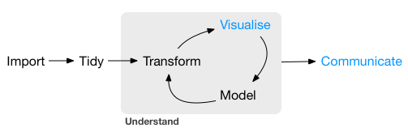

## `gganimate` Basics & Examples

- `gganimate` is primarily applied to ggplot objects by specifying transitions to use
- There are 4 primary transition functions that will be covered:
  - `transition_time()`
  - `transition_reveal()`
  - `transition_filter()`
  - `transition_states()`

## Getting Started

Getting started with `gganimate` could not be easier!

To start, create a regular `ggplot`. Then, add a transition layer based on what you want to change

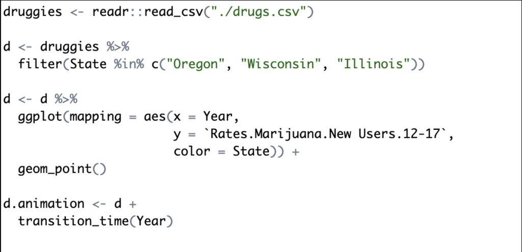

## `transition_time()`

- `transition_time()` is useful for showing differences in variables over time
- This is a very intuitive and interesting way to show time
- You can also make time a third variable in a two-dimensional graph

Let’s look at the example from the last slide

## `transition_time()` Example

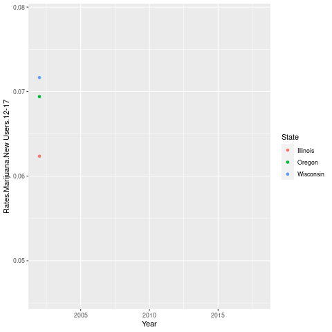

This is not very clear, since the trends are very hard to see

Let’s fix that!

## `shadow_trail()`

- `shadow_trail` and will keep points behind the moving value, called a shadow
- This allows the trends to be easier to see

## `shadow_trail()` Example

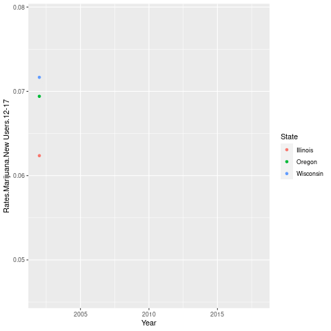

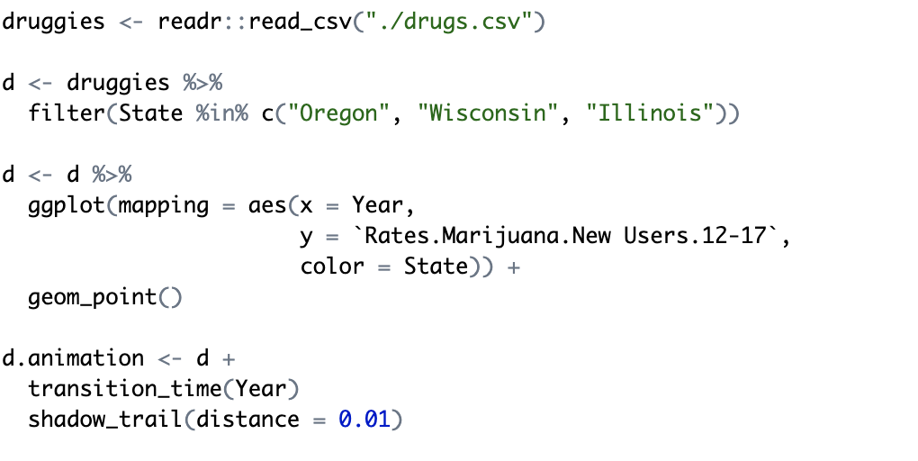

## `transition_time()` vs `transition_reveal()`

- The plot on the left shows all the seasons in NBA history in which a player averaged at least 30 points per game
- On the right the plot is animated using `transition_time()`

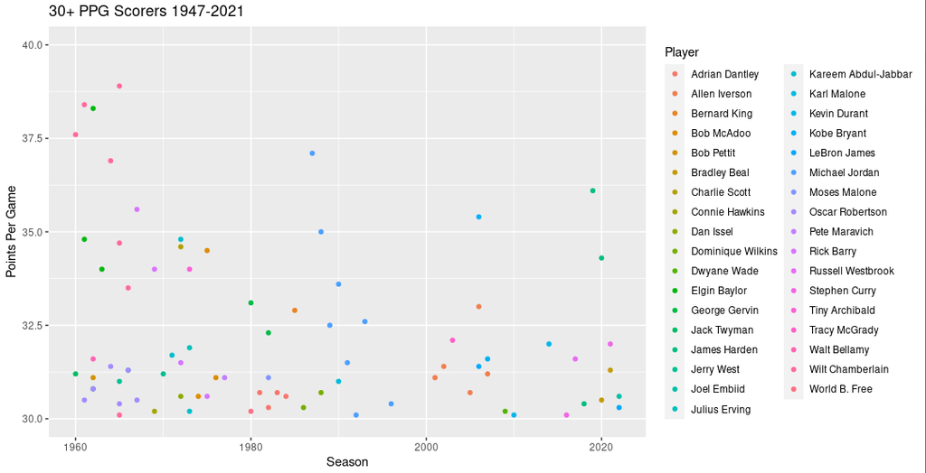

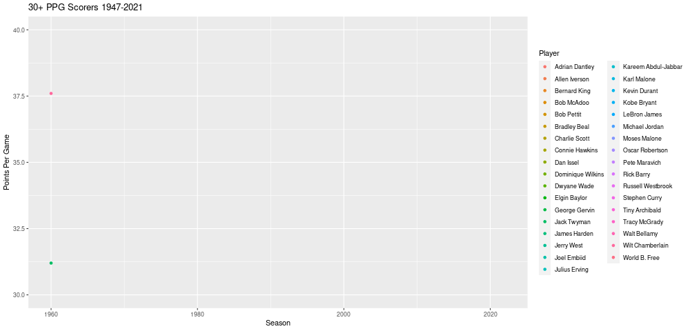

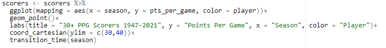

- Once again, the animation does not communicate much since the points disappear very quickly

## `transition_time()` vs `transition_reveal()`

- Instead of using `shadow_trails`, we can see what the whole plot looks like using `transition_reveal()`
- The animation on the left uses `transition_time()` and the animation on the right uses `transition_reveal()`

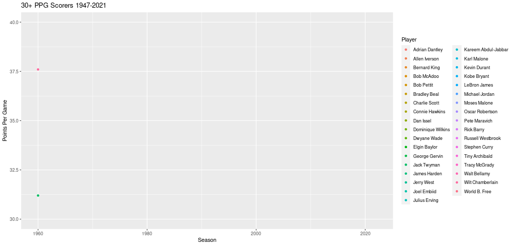

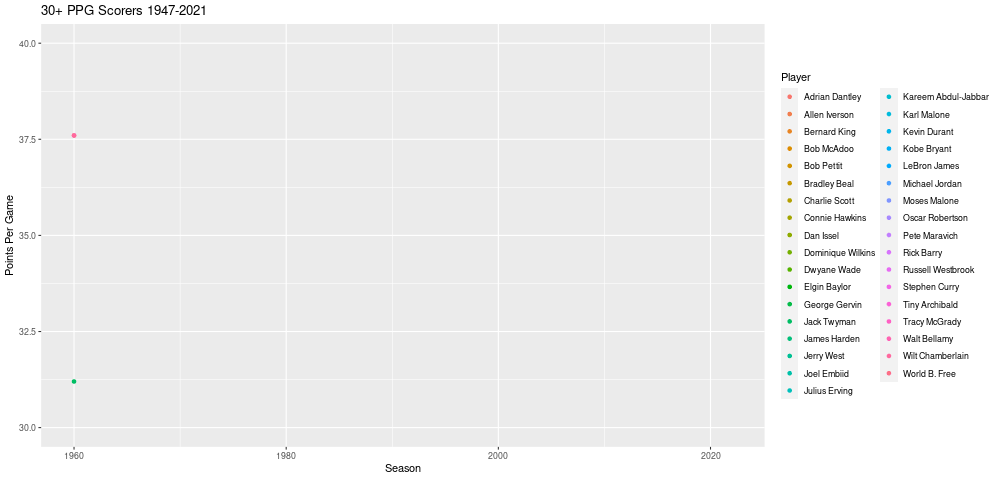

- `transition_reveal()` does a much better job of communicating the data than `transition_time()` on its own

## `shadow_wake()`

- The animation can still be improved though. Any player that occurs on the list multiple times is only on the plot once
- Using the `shadow_wake()` function of `gganimate`, we can add a wake to these players to show their scoring over their career
- `shadow_wake()` is similar to `shadow_trail()`, but the points eventually fade
- The amount of time the points stay visible can be set with `wake_length`

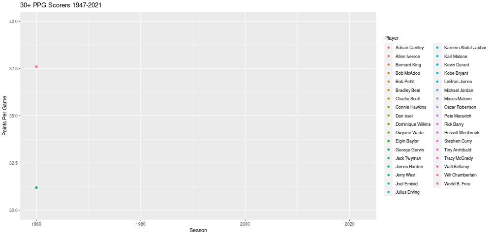

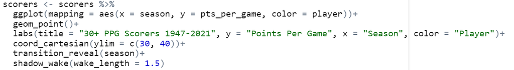

## `shadow_wake()`

- Here are the animations side by side

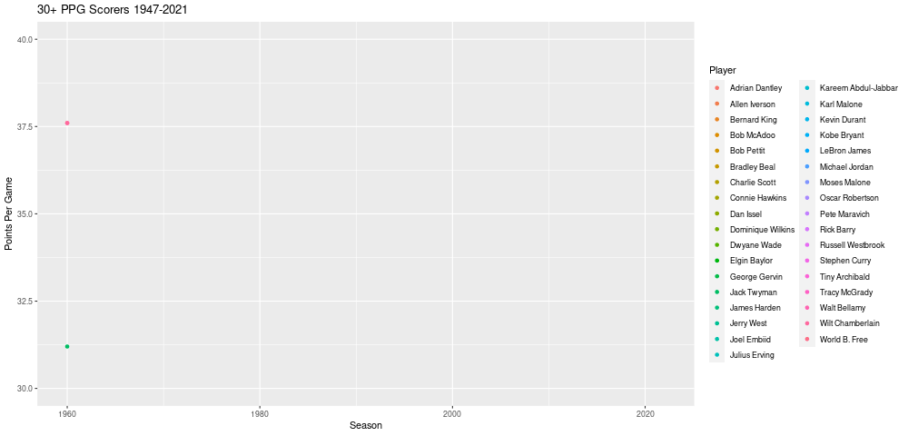

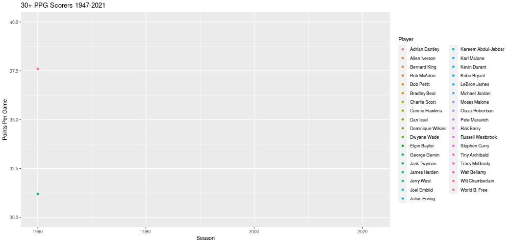

- `Shadow_wake()` communicates who the most productive players were over the course of their career instead of just a single season

## `transition_filter()`

- The plot below shows all the cars in mtcars on a scatter plot with miles per gallon on the x-axis and horsepower on the y-axis
- This plot does not communicate much aside from the relationship between horsepower and miles per gallon

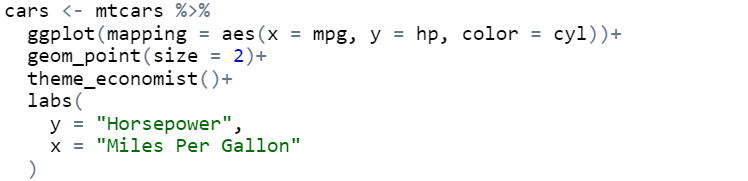

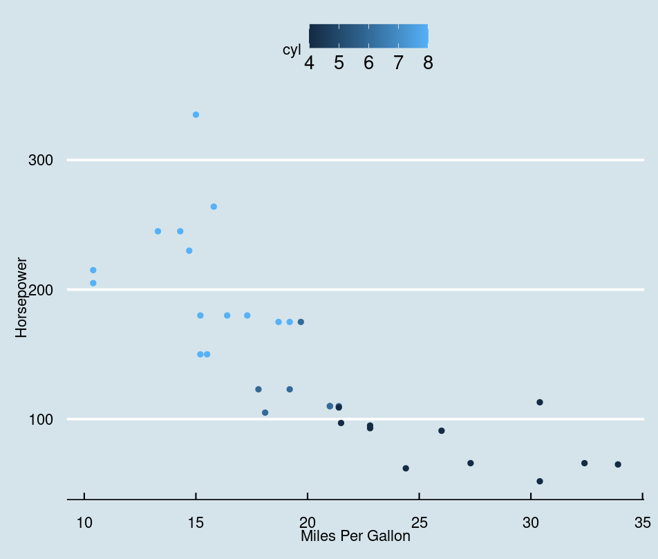

- Some simple animation could improve this plot

## `transition_filter()`

- `transition_filter()` creates an animation that cycles through different filters of the data
- We can use other variables from mtcars other than hp and mpg to set filters
- This can be used as an alternative to faceting

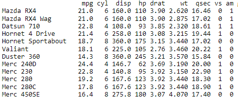

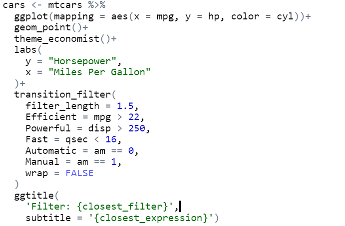

## tranistion_filter()

- Once the transition_filter() function is applied our static plot is transformed into a more informative animation

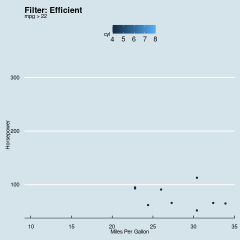

- The animation communicates trends within certain filters that would not be shown in a single, static plot

## `transition_states()`

- `transition_states()` is useful for non-time related transitions between data
- Also can make use of other fields or options to improve animation

So, let’s look at an example

## `transition_states()` Example(1)

- Suppose we look at some simulated data of a BJT transistor circuit component:
- The output behavior of the component generally looked at is voltage vs current
- In this case, that would be Vce vs. Ic

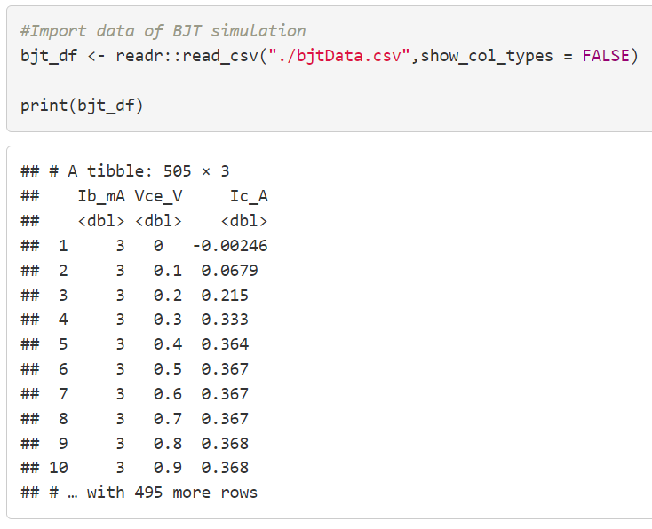

## `transition_states()` Example(2)

- The output function also depends on an input current Ib, however, and varies accordingly
- As such, we get the following `ggplot`

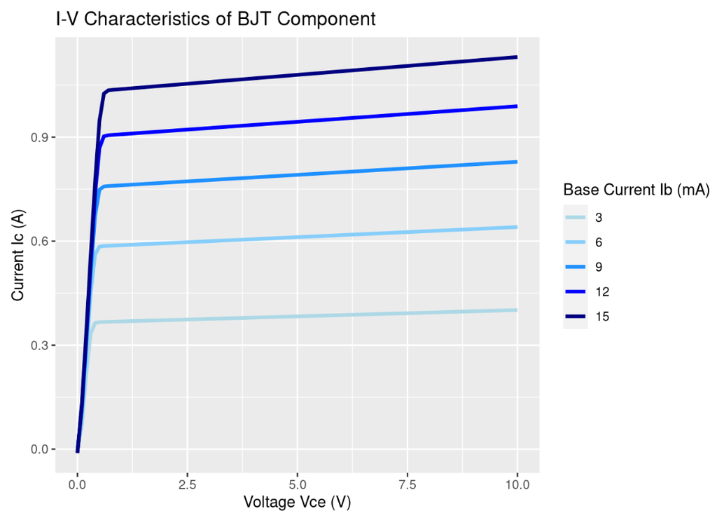

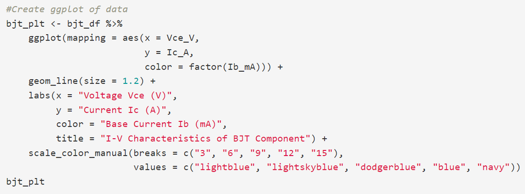

## `transition_states()` Example(3)

- Showing the data in this format indicates the behavior, but we can improve it is communicated
- Applying state transitions to the Ib value, the behavior can then be made into the following animated plot

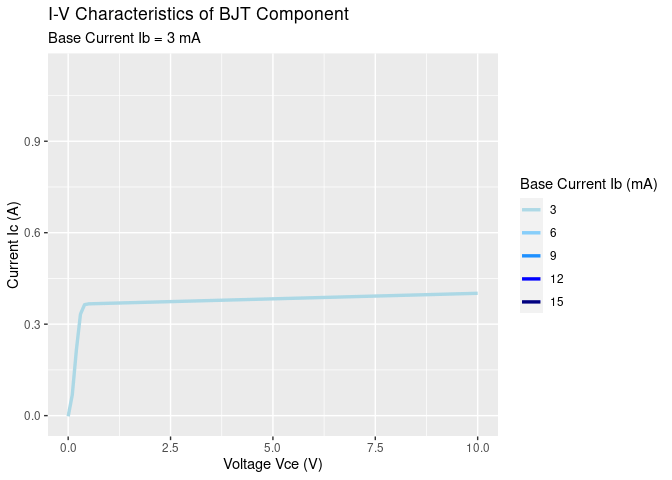

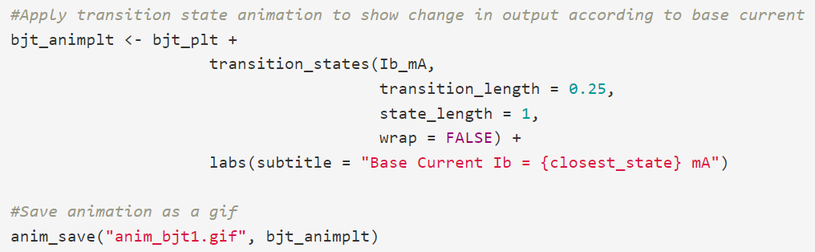

## `transition_states()` Example(4)

- This better indicates how the function output behavior increases as Ib increases
- Furthermore, making use of `shadow_mark()`, we can then add onto the existing plot
  - `shadow_mark()` is similar to `shadow_trail()`, however it leaves a mark at the data state

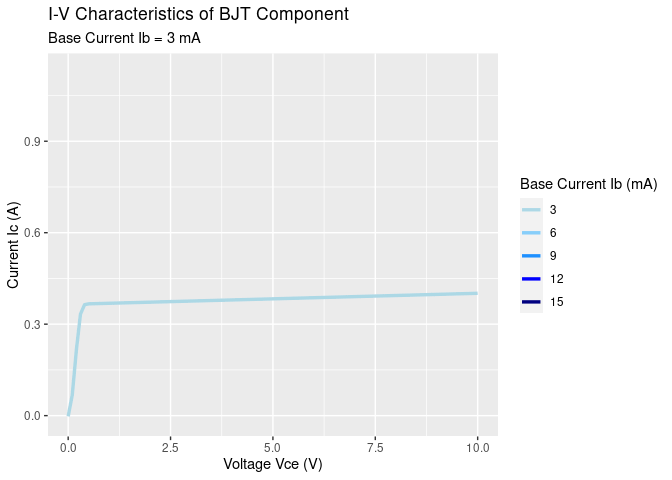

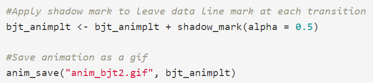